# 543 Lab 2

Emelie

22/11/2023

# Exercise 1

In Lecture 3 on Probability Sampling we saw an example regarding the final grades of 116 students from a previous course. Consider the grades.csv file uploaded on CANVAS which contains the grades for all 116 students. In this lab we will we compute confidence intervals for this population of students based on SRS.

# Confidence Intervals

Our first goal is to conduct a 95% confidence interval for the average grade in this class based on a sample of size 10. As a first step, we read in the data.

```r
Data <- read.csv("grades.csv")
head(Data)
```

```
##   id grade
## 1  1    95
## 2  2    83
## 3  3    84
## 4  4    86
## 5  5    67
## 6  6    71
```

We will set a seed for reproducibility.

```r
set.seed(543)
Sample <- sample(Data$grade,10)
```

Calculate the sample average and variance.

```r
mu.hat <- mean(Sample)
var.hat <- var(Sample)
```

Store the sample size and population size

```r
n <- length(Sample)
N <- length(Data$grade)
```

Compute lower and upper CI for the population average

```r
conf = 0.95 # confidence level
alpha = 1-conf # significance level
# divide the significance level across 2 tails
# to find the value of z such that
# P(Z < -cval) or P(Z > cval) = 0.05
# qnorm(alpha/2) # gives us -cval
cval <- qnorm(alpha/2, lower.tail = FALSE) # gives us cval

# standard error of mu hat
se.mu.hat = sqrt((1 - n/N)*(var.hat/n))

CI.l <- mu.hat - cval*se.mu.hat
CI.u <- mu.hat + cval*se.mu.hat
round( c(CI.l, CI.u),1)
```

```
## [1] 73.9 85.9
```

Alternatively we could save it in a vector `CI` in the following way:

```r
CI <- mu.hat + c(-1,1)*cval*se.mu.hat
```

The confidence interval is 73.861, 85.939

# Coverage Probability

We now compute the coverage probability based on `m = 10000` repetitions. Since we have access to the entire population, we know that the true population average is equal to:

```r
muy = mean(Data$grade)
muy
```

```
## [1] 78.81034
```

Let’s see how many 95% CI for $\mu$ based on a sample of size 10 contain the true value of $\mu =$ 78.8103448. We will save this information in matrix `sim2`. Each row of `sim2` will correspond to a single repetition and the first, second and third column will contain the point estimate, lower 95% CI bound and upper 95% CI bound, respectively.

```r
m = 10^4
n = 10
sim2 = matrix(0, nrow=m, ncol=3)
conf = 0.95 # confidence level
alpha = 1-conf # significance level
cval <- qnorm(alpha/2, lower.tail = FALSE)

set.seed(543)
for (i in 1:m) {
  sample1 = sample(N, 10)
  sample1y =  Data$grade[sample1]

  mu.hat = mean(sample1y)
  se.hat = sqrt( (1-n/N)*var(sample1y)/n   )

  ci.mu = mu.hat + c(-1,1)*cval*se.hat

  sim2[i, 1] = mu.hat
  sim2[i, 2:3] = ci.mu
}
```

An estimate of the coverage probability can therefore be calculated by counting the number of times 78.8103448 is contained between the lower 95% CI bound (stored in `sig2[,2]`) and upper 95% CI bound (stored in `sig2[,3]`).

```r
coverage1 = mean(muy > sim2[,2] & muy < sim2[,3])
```

The estimated coverage for a sample size of 10 is 91.42%.

A useful visual to go along with this number is provided below:

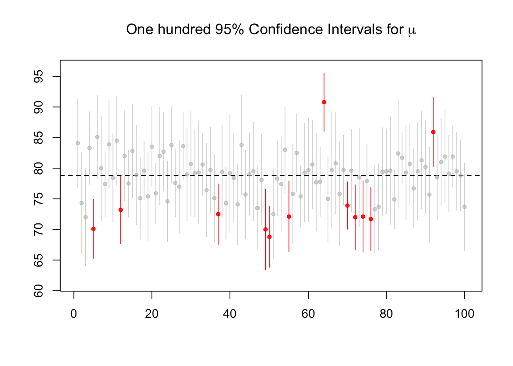

```r
m1 = 100
# for ease of viewing lets just look at 100 random CIs from m
subset = sample(m, size=m1)

# create an logical vector 1=CI contained muy 0=otherwise
covered.mu=as.numeric(muy > sim2[subset,2] & muy < sim2[subset,3])

# used for plotting
two.colours = c(adjustcolor("Red", 0.9), adjustcolor("Grey", 0.6))

plot(x=c(1,1), y=sim2[subset[1],2:3], xlim=c(0, m1)+1/2,
     main=expression("One hundred 95% Confidence Intervals for "*mu),
     type='l', ylab="",xlab="", ylim=range(sim2[,2:3]),
     col= two.colours[covered.mu[1] +1 ])

# create grey CI for those which contained muy
# and red CI for those which did not contain muy
for (i in 2:m1) {
  lines(x=c(i,i), sim2[subset[i],2:3],
        col= two.colours[covered.mu[i] +1 ])
}

# create a horizontal dashed line indicating where the
# true population mean muy falls
abline(h=muy, col=1, lty=2)

# plot the point estimates for each CI:
points(1:m1, sim2[subset,1],pch=20, col= two.colours[covered.mu +1 ])
```

Let’s find the estimated coverage for various sample sizes $n$.

```r
m = 10^4
n = seq(10,60,3)
# n = c(10, 30) # comment out for lab
sim3 = numeric(length(n))

# set seed for reproducibility
set.seed(543)
for (j in 1:length(n)) {
  temp  = numeric(m)
  for (i in 1:m) {
    sample1 = sample(N, n[j])
    sample1y =  Data$grade[sample1]

    mu.hat = mean(sample1y)
    se.hat = sqrt( (1-n[j]/N)*var(sample1y)/n[j]   )
    ci.mu = mu.hat + c(-1,1)*cval*se.hat

    temp[i] = as.numeric( muy > ci.mu[1] & muy < ci.mu[2] )
  }
  sim3[j] = mean(temp)
}
```

Finally lets graph of the estimated coverage probability versus sample size.

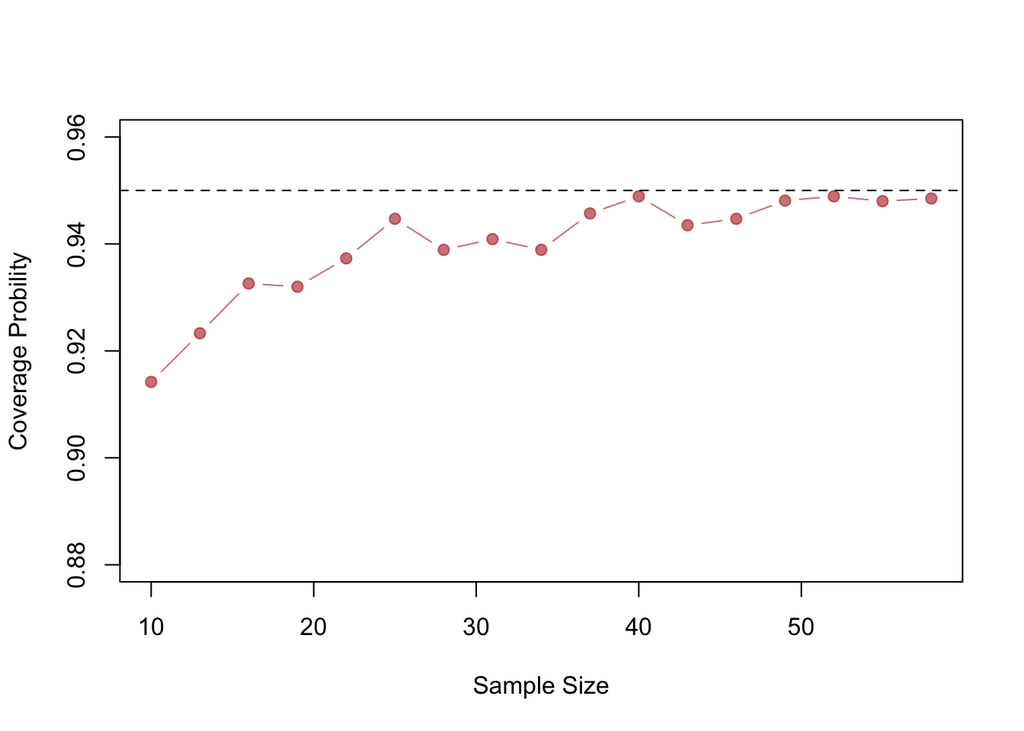

```r
plot(n, sim3, xlab="Sample Size", ylab="Coverage Probility", ylim=c(.88,.96), pch=19, col=adjustcolor("firebrick", .6), type='b' )
abline(h=.95,lty=2)
```

# Exercise 2

In Lecture 4, we looked at one question open to all graduates and undergraduates (31,631 students total) from a particular university, lets call it Monsters University. The question asked whether students used LinkedIn at least once a week. The report provides some results broken down by faculty which we used as strata. Side note: We might also consider stratifying by graduation year.

Here are the faculty names;

```r
faculty <- c("AHS","Arts","Eng","Env","Math","Sci")
```

total number of students in each faculty;

```r
population <- c(2434,6661,7998,2503,6661,5374)
population
```

```
## [1] 2434 6661 7998 2503 6661 5374
```

and sample size in each faculty;

```r
sample <- c(149,341,202,119,165,223)
sample
```

```
## [1] 149 341 202 119 165 223
```

Here are the results for the LinkedIn question (so, e.g., 13% of Applied Health Sciences students said they used LinkedIn at least once a week).

```r
linkedin <- c(0.13,0.26,0.34,0.32,0.29,0.18)
linkedin
```

```
## [1] 0.13 0.26 0.34 0.32 0.29 0.18
```

Lets store this information in a data frame:

```r
temp = data.frame(faculty, population, sample, linkedin)
temp
```

```
##   faculty population sample linkedin
## 1     AHS       2434    149     0.13
## 2    Arts       6661    341     0.26
## 3     Eng       7998    202     0.34
## 4     Env       2503    119     0.32
## 5    Math       6661    165     0.29
## 6     Sci       5374    223     0.18
```

We may choose to create new variables to make the code easier to understand:

```r
Nh   <- population
Wh   <- population/sum(population)
fh   <- sample/population
nh   <- sample
n    <- sum(sample)
wh   <- sample/n
pih  <- linkedin
temp = data.frame(faculty, Nh, Wh, nh, wh, pih)
format(temp,digits=2)
```

```
##   faculty   Nh    Wh  nh    wh  pih
## 1     AHS 2434 0.077 149 0.124 0.13
## 2    Arts 6661 0.211 341 0.284 0.26
## 3     Eng 7998 0.253 202 0.168 0.34
## 4     Env 2503 0.079 119 0.099 0.32
## 5    Math 6661 0.211 165 0.138 0.29
## 6     Sci 5374 0.170 223 0.186 0.18
```

Based on these figures, using the faculty to strata seems like a good thing because there are differences among the strata averages ($\widehat{\pi}_h$). The exception seems that Eng and Env have similar responses.

To check which faculties are over/under-represented:

```r
faculty[Wh > wh]
```

```
## [1] "Eng"  "Math"
```

```r
faculty[Wh < wh]
```

```
## [1] "AHS"  "Arts" "Env"  "Sci"
```

# Estimates for $\pi$

The overall sample estimate or the ``raw” sample average is $\widehat{\pi} = \sum \frac{n_h}{n} \widehat{\pi}_h =$ 0.253

```r
pi.strata.hat = sum(Wh *pih)
round(pi.strata.hat,3)
```

```
## [1] 0.268
```

Using our knowledge of the population-level stratum weights, our stratified sample estimate is $\widehat{\pi}_{s} = \sum W_h \widehat{\pi}_h =$ 0.268

```r
sum(Wh^2 * (1-fh)/nh * pih * (1 - pih))
```

```
## [1] 0.0001803758
```

To calculate a confidence interval or to quantify the sampling error we need a standard error. We can also use the SRSWOR result for the variance of the estimator:
$$Var(\widetilde{\mu}_s) = \sum\limits_{h=1}^H W_h^2 \left(1 -
\frac{n_h}{N_h}\right)\frac{\sigma_h^2}{n_h}$$

For large $n$ we can use the approximation
$$\sigma^2 \approx \pi \left(
1- \pi \right)$$
$$Var(\widetilde{\pi}_h) \approx \left( 1-f_h
\right) \frac{\pi_h(1-\pi_h)}{n_h}$$

$$\widehat{Var}(\widetilde{\pi}_s) =
\sum\limits_{h=1}^H W_h^2 \left( 1-f_h \right) \frac{
\widehat{\pi}_h(1-\widehat{\pi}_h)}{n_h}$$

Conveniently, this means we don’t need to know any stratum-level sample variances!

```r
sigma2.hat.h = pih*(1-pih)
sum(Wh^2 * (1-fh)*sigma2.hat.h/nh )
```

```
## [1] 0.0001803758
```

```r
se.pi.strata = sqrt(sum(Wh^2 * (1-fh)*sigma2.hat.h/nh ))
se.pi.strata
```

```
## [1] 0.0134304
```

The standard error for the strata estimate is 0.0134

```r
alpha = 0.05
Zval  = qnorm(1-alpha/2)
strata.ci = pi.strata.hat + c(-1,+1) * Zval * se.pi.strata
round(strata.ci,3)
```

```
## [1] 0.241 0.294
```

So a 95% CI for the population proportion is 0.241, 0.294

## Proportional Allocation

We can modify $n_1, n_2, \ldots, n_H$ or equivalently the sampling weights $w_h = \frac{n_h}{n}$.

If the sampling weights are equal to the population weights we have **proportional allocation**. Mathematically, this means
$$\frac{n_h}{n} = \frac{N_h}{N}
\qquad\mbox{so}\qquad
\frac{n}{N} = \frac{n_h}{N_h}
\qquad\mbox{and}\qquad
n_h \propto N_h$$

The previous survey has a sample size of

```r
nh
```

```
## [1] 149 341 202 119 165 223
```

```r
sum(n)
```

```
## [1] 1199
```

```r
round(n*Wh,0)
```

```
## [1]  92 252 303  95 252 204
```

```r
data.frame(faculty, proportional.allocation = round(n*Wh,0) )
```

```
##   faculty proportional.allocation
## 1     AHS                      92
## 2    Arts                     252
## 3     Eng                     303
## 4     Env                      95
## 5    Math                     252
## 6     Sci                     204
```

Comparing the two

```r
data.frame(faculty, study.One=nh, proportional = round(n*Wh,0) )
```

```
##   faculty study.One proportional
## 1     AHS       149           92
## 2    Arts       341          252
## 3     Eng       202          303
## 4     Env       119           95
## 5    Math       165          252
## 6     Sci       223          204
```

# Exercise 3

Let’s revisit the Block Data that we studied in the Lab 1 and consider forming strata and using proportional allocation.

- The goal is to estimate the population parameter average.
- We can form varying strata using the block weights
- and compare to simple random sampling without replacement (SRSWOR).

Recall: in the case of proportional allocation, we showed that
$$Var(\widetilde{\mu}_s) = \frac{1}{n}\left(1 -
\frac{n}{N}\right)\sum\limits_{h=1}^H W_h\sigma_h^2$$

and using simple random sampling without replacement (SRSWOR):
$$Var(\widetilde{\mu}) = \frac{1}{n}\left(1 -
\frac{n}{N}\right) \sigma^2$$

Comparing the variance of the stratified sample estimator (via proportional allocation) with that of SRSWOR tells us that the stratified estimator variance will be lower if
$$\sum\limits_{h=1}^H W_h\sigma_h^2 < \sigma^2$$

Lets investigate this results using the following data:

```r
blocks = read.csv("Blocks.csv", header=TRUE)
mu.per = mean(blocks$Perimeter)
mu.wts = mean(blocks$Weights)
N = nrow(blocks)
```

The population average weight, $\mu_{weights}$, is known to be 47.94

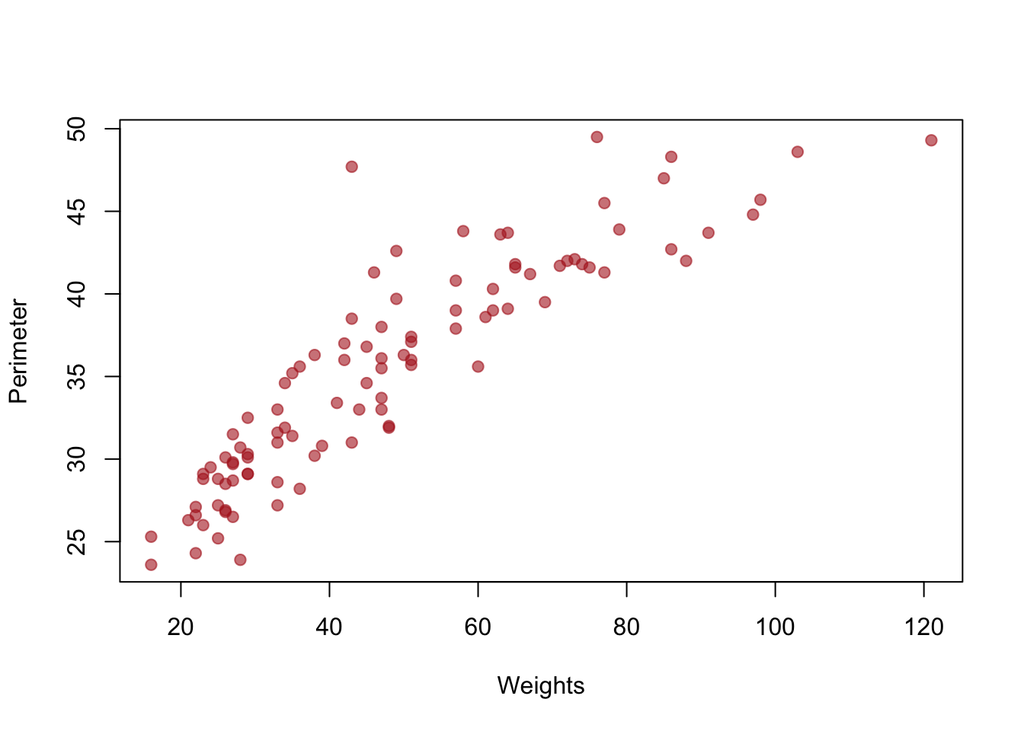

```r
plot(blocks[,c(2,3)], col=adjustcolor("firebrick", 0.6), pch=19)
```

```r
summary.strata <- function(y=NULL, strata=NULL, labels=NULL) {
  ## y is a numerical vector
  ## strata is vector containing strata allocations
  ## label is vector of the strata names

  Nh = table(strata)
  Wh = Nh/length(strata)

  temp = aggregate(y, by=list(strata), FUN=function(z) { c(mean(z), var(z))   })
  temp = as.matrix(temp)[,-1]
  temp = as.data.frame(temp)
  temp[,3] = Wh

  if (is.null(labels)) temp[,4] = 1:length(Wh)
  else temp[,4] = labels


  names(temp) = c("Average", "Variance", "Weight", "Strata")
  temp = temp[,c(4,3,1,2)]
  return(temp)
}
```

Let’s consider forming strata based on the weight of the blocks.

```r
strata = numeric(N)
strata[blocks$Weights < 40] = 1
strata[blocks$Weights >= 40] = 2
nam1= c("Light", "Heavy")
```

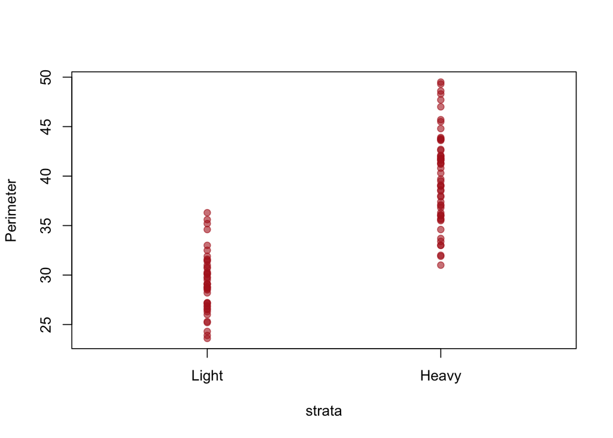

```r
plot(strata, blocks$Perimeter, col=adjustcolor("firebrick", 0.6), pch=19, xlim=c(0.5,2.5), xaxt='n', ylab="Perimeter")
axis(1, labels=nam1, at=1:2)
```

The stratum weights are:

```r
Wh = table(strata)/length(strata)
Wh
```

```
## strata
##    1    2
## 0.43 0.57
```

The stratum variances are:

```r
sigma2.h= numeric(2)
sigma2.h[1] = var(blocks$Perimeter[strata == 1])
sigma2.h[2] = var(blocks$Perimeter[strata == 2])
sigma2.h
```

```
## [1]  9.304928 21.791435
```

The variance term under proportional allocation is

```r
sum(Wh *sigma2.h)
```

```
## [1] 16.42224
```

The variance term under simple random samling without replacement (SRSWOR) is the population variance given by

```r
var(blocks$Perimeter)
```

```
## [1] 45.02463
```

When comparing the stratified sampling with proportional allocation and simple random samling without replacement (SRSWOR) we have that

- The variance term under proportional allocation is 16.42
- The variance term under SRSWOR is 45.02

Hence, stratification produces a more precise estimate that SRSWOR.

```r
temp = summary.strata(y=blocks$Perimeter, strata=strata, labels=nam1)
format(temp, digits=3)
```

```
##   Strata Weight Average Variance
## 1  Light   0.43    29.2      9.3
## 2  Heavy   0.57    40.0     21.8
```

In the case of proportional allocation,
$$Var(\widetilde{\mu}_s) = \frac{1}{n}\left(1 -
\frac{n}{N}\right)\sum\limits_{h=1}^H W_h\sigma_h^2$$

```r
n=30 # say
1/n*(1-n/N)*sum(Wh *sigma2.h)
```

```
## [1] 0.3831855
```

and using simple random samling without replacement (SRSWOR):
$$Var(\widetilde{\mu}) = \frac{1}{n}\left(1 -
\frac{n}{N}\right) \sigma^2$$

```r
1/n*(1-n/N)*var(blocks$Perimeter)
```

```
## [1] 1.050575
```

# Strata Two

Consider forming strata based on block weights.

```r
strata = numeric(N)
strata[blocks$Weights < 40] = 1
strata[blocks$Weights >= 40 & blocks$Weights < 60] = 2
strata[blocks$Weights >= 60] = 3

nam3 = c("Light", "Medium", "Heavy")
```

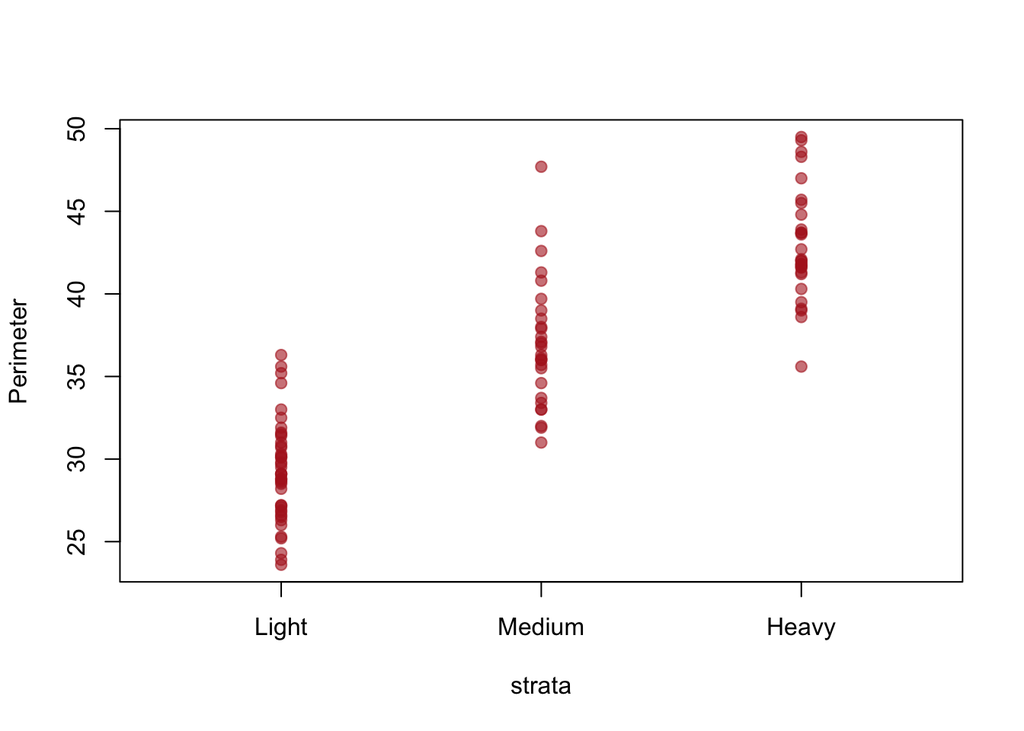

```r
plot(strata, blocks$Perimeter, col=adjustcolor("firebrick", 0.6), pch=19, xlim=c(0.5,3.5), xaxt='n', ylab="Perimeter")
axis(1, labels=nam3, at=1:3)
```

The stratum weights are:

```r
Wh = table(strata)/length(strata)
Wh
```

```
## strata
##    1    2    3
## 0.43 0.28 0.29
```

The stratum variances are:

```r
sigma2.h= numeric(3)
sigma2.h[1] = var(blocks$Perimeter[strata == 1])
sigma2.h[2] = var(blocks$Perimeter[strata == 2])
sigma2.h[3] = var(blocks$Perimeter[strata == 3])
sigma2.h
```

```
## [1]  9.304928 14.682910 11.379729
```

The variance term under proportional allocation is

```r
sum(Wh *sigma2.h  )
```

```
## [1] 11.41246
```

The variance term under simple random samling without replacement (SRSWOR) is the population variance given by

```r
var(blocks$Perimeter)
```

```
## [1] 45.02463
```

When comparing the stratified sampling with proportional allocation and simple random samling without replacement (SRSWOR) we have that

- The variance term under proportional allocation is 11.41
- The variance term under SRSWOR is 45.02

```r
temp = summary.strata(y=blocks$Perimeter, strata=strata, labels=nam3)
format(temp, digits=3)
```

```
##   Strata Weight Average Variance
## 1  Light   0.43    29.2      9.3
## 2 Medium   0.28    37.0     14.7
## 3  Heavy   0.29    42.9     11.4
```

In the case of proportional allocation,
$$Var(\widetilde{\mu}_s) = \frac{1}{n}\left(1 -
\frac{n}{N}\right)\sum\limits_{h=1}^H W_h\sigma_h^2$$

```r
n=30 # say
1/n*(1-n/N)*sum(Wh *sigma2.h)
```

```
## [1] 0.2662906
```

and using simple random samling without replacement (SRSWOR):
$$Var(\widetilde{\mu}) = \frac{1}{n}\left(1 -
\frac{n}{N}\right) \sigma^2$$

```r
1/n*(1-n/N)*var(blocks$Perimeter)
```

```
## [1] 1.050575
```

## Strata Three

Consider forming strata randomly

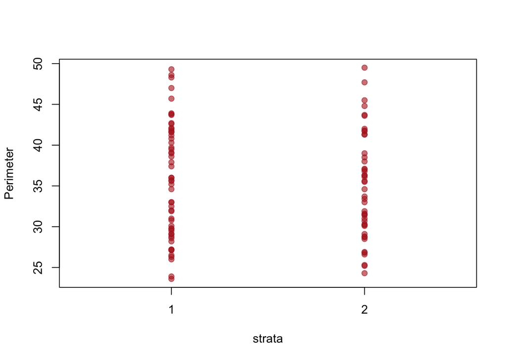

```r
set.seed(543543)
sam1 = sample(1:100, 55)
strata = rep(2,100)
strata[sam1] = 1
plot(strata, blocks$Perimeter, col=adjustcolor("firebrick", 0.6), pch=19, xlim=c(0.5,2.5), xaxt='n', ylab="Perimeter")
axis(1, labels=c(1,2), at=1:2)
```

The stratum weighs

```r
Wh = table(strata)/length(strata)
Wh
```

```
## strata
##    1    2
## 0.55 0.45
```

The stratum variances

```r
sigma2.h= numeric(2)
sigma2.h[1] = var(blocks$Perimeter[strata == 1])
sigma2.h[2] = var(blocks$Perimeter[strata == 2])
round(sigma2.h,2)
```

```
## [1] 48.50 41.42
```

The variance term under proportional allocation is

```r
sum(Wh *sigma2.h  )
```

```
## [1] 45.31512
```

The variance term under simple random samling without replacement (SRSWOR) is the population variance given by

```r
var(blocks$Perimeter)
```

```
## [1] 45.02463
```

When comparing the stratified sampling with proportional allocation and simple random samling without replacement (SRSWOR) we have that

- The variance term under proportional allocation is 45.32
- The variance term under SRSWOR is 45.02

```r
temp = summary.strata(y=blocks$Perimeter, strata=strata)
format(temp, digits=3)
```

```
##   Strata Weight Average Variance
## 1      1   0.55    35.7     48.5
## 2      2   0.45    34.9     41.4
```

In the case of proportional allocation,
$$Var(\widetilde{\mu}_s) = \frac{1}{n}\left(1 -
\frac{n}{N}\right)\sum\limits_{h=1}^H W_h\sigma_h^2$$

```r
n=30 # say
1/n*(1-n/N)*sum(Wh *sigma2.h)
```

```
## [1] 1.057353
```

and using simple random samling without replacement (SRSWOR):
$$Var(\widetilde{\mu}) = \frac{1}{n}\left(1 -
\frac{n}{N}\right) \sigma^2$$

```r
1/n*(1-n/N)*var(blocks$Perimeter)
```

```
## [1] 1.050575
```

As we can see from this last example, when strata are not chosen carefully, stratification actually can hurt our estimation procedure.